# PCA with chemospec demo

Ndung’u Ndegwa Charles

3/31/2020

## Package installation

You need to make sure that you have all the neccesary packages already installed before proceding. i demonstrated how to install missing packages in the session we had so we will not repeat the process here.

## Loading the packages we will use

```r
library(ChemoSpecUtils)
library(ChemoSpec)
library(chemometrics)
library(knitr)
library(R.utils)
library(utils)
library(kableExtra)
```

## Metadata

We will use a DRS spectra data set for demonstration. The data set is from spinach leaves sprayed with two agrochemicals “BF” and “M72” and a control sample named “CS”. the data was collected using an ocean optics USB 2000 portable spectrometer at the Laser and spectroscopy lab, department of physics, University of Nairobi in 2019 at room temperature. The frequency scale runs from 349.9 nm to 1000.6 (nm).

## Reading a matrix data file stored in the working directory

Ensure first that you have set the working directory where your data is located, idealy on your desktop in a folder for easier access.

```r
rawspec <- matrix2SpectraObject(gr.crit = c("cs", "bf","m72"),
                                gr.cols = c("green","red","blue"),
                                freq.unit = "Wavelength (nm)",
                                int.unit = "Reflectance (%)",
                                descrip = "ACR Study",
                                in.file = "ACR_DRS_spectra.csv",
                                out.file = "ACR_data",
                                chk = TRUE,
                                sep = ",",
                                dec = ".")
```

```
##
## Reading 1 file(s)...
```

```
##
## Assigning 567 spectra to 3 group(s)...
```

As it can be seen clearly, the data has 567 spectra and 3 groups from the group criteria, “CS”,“BF” and “M72”

## Summary of the data

We can look at our data summary using the “sumSpectra” function available in chemospec

```r
sumSpectra(rawspec)
```

```
##
##  ACR Study
##
##  There are 567 spectra in this set.
##  The y-axis unit is Reflectance (%).
##
##  The frequency scale runs from
##  349.9 to 1000.6 Wavelength (nm)
##  There are 2048 frequency values.
##  The frequency resolution is
##  0.32 Wavelength (nm)/point.
##
##
##  The spectra are divided into 3 groups:
##
##   group no. color symbol alt.sym
## 1    bf 214   red      1       b
## 2    cs  94 green      0       a
## 3   m72 259  blue      2       c
##
##
## *** Note: this is an S3 object
## of class 'Spectra'
```

we can visualize the spectra using the “plotSpectra” function and colour them according to the colour criteria that we had specified.

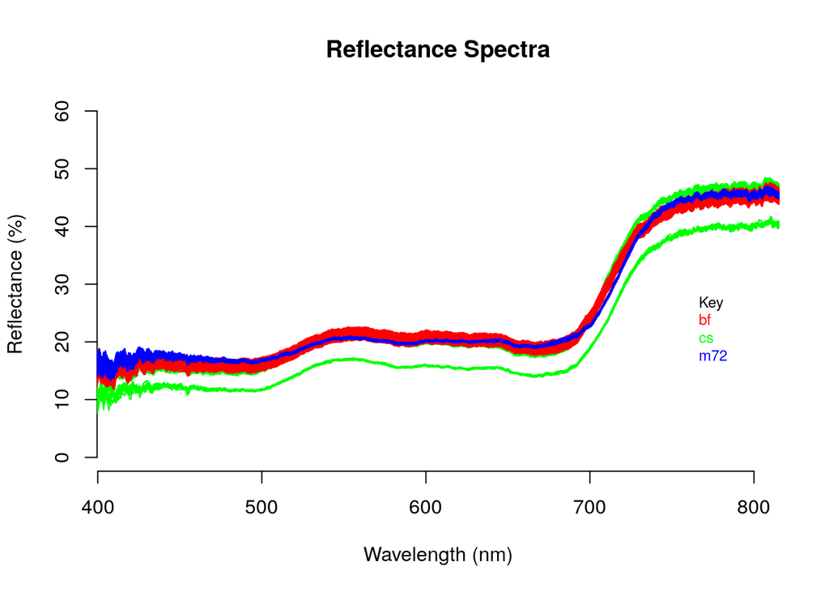

```r
plotSpectra(rawspec,
            main = "Reflectance Spectra",
            which = c(1:436),
            yrange = c(0,60),
            xlim =c(415,800),
            offset = .01,
            showGrid = FALSE,
            lab.pos = 4000,
            leg.loc = list(x = 750, y = 30))
```

We can choose to plot one spectrum from each category.

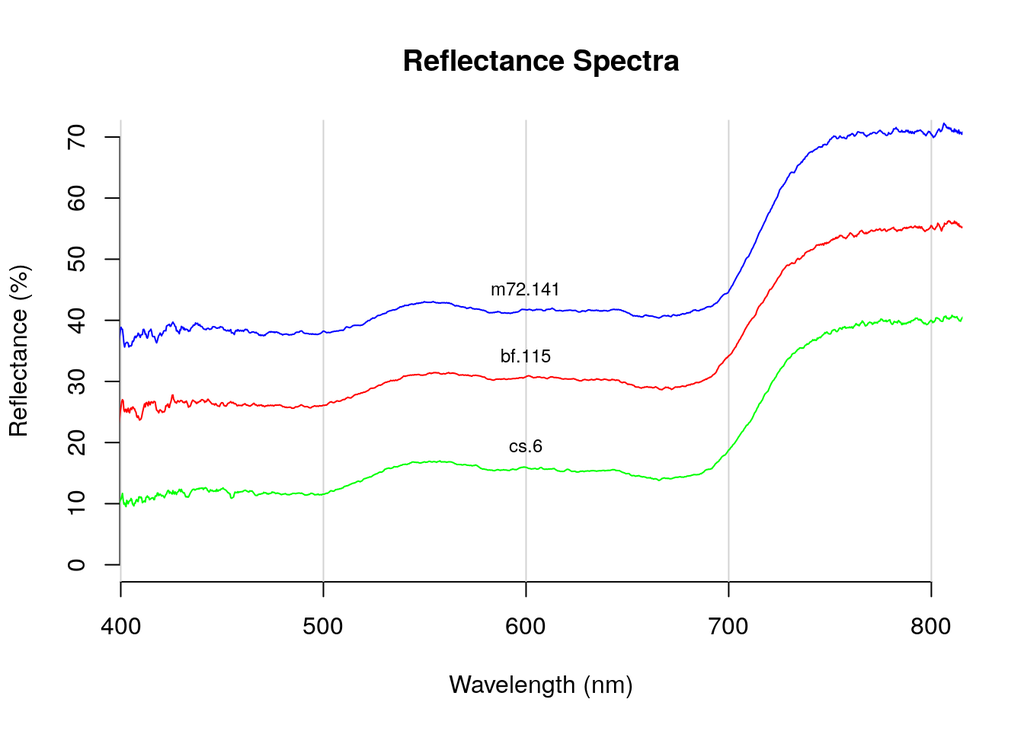

```r
plotSpectra(rawspec,
            main = "Reflectance Spectra",
            which = c(7,210,450),
            yrange = c(0,70),
            xlim =c(415,800),
            offset = 12,
            lab.pos = 600)
```

## Wavelength selection

We can specify the frequencies range we desire using the “removeFreq” function. In this example, i am selecting the wavelengths between 680 nm to 800 nm region for further analysis

```r
newspec <- removeFreq(rawspec, rem.freq = rawspec$freq > 800| rawspec$freq < 680)
```

## Pre-processing spectra

In this example,we will only do normalization of data using the “normSpectra” function.

```r
spec3<-normSpectra(newspec)
```

## PCA analysis

Now our data is ready for PCA analysis,You have two main options, either classical methods, or robust methods. Clas- sical methods use all the data you provide to compute the scores and loadings. Robust methods focus on the core or heart of the data, which means that some samples may be downweighted. This difference is important, and the results from the two methods may be quite different, depending upon your the nature of your data. The differences arise because PCA methods (both classical and robust) attempt to find the components that explain as much of the variance in the data set as possible. If you have a sample that is genuinely corrupted, for instance due to sample handling, its spectral profile may be very different from all other sam- ples, and it can legitimately be called an outlier. In classical PCA, this one sample will contribute strongly to the variance of the entire data set, and the PCA scores will reflect that (it is sometimes said that scores and loadings follow the outliers). With robust PCA, samples with rather different characteristics do not have as great an influence, because robust measures of variance, such as the median absolute deviation, are used.

More information can be found on the PDF files i had shared with you “An Introduction to ChemoSpec” .

```r
pca<-c_pcaSpectra(spec3, choice = "noscale", cent = TRUE)
```

## Score plots

This can be a 2D or 3D plot showing how clustered our data is

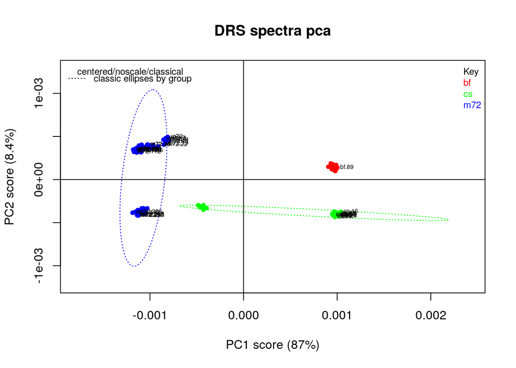

```r
plotScores(spec3, pca,
             main ="DRS spectra pca", pcs = c(1,2), ellipse = "cls", tol = 0.05)
abline(v=0,h=0)
```

## loadings plot

Loadings plot tells how each variable (frequencies in spectral applications) affect the scores. Examining these loadings can be critical to interpreting your results(Scores Plot).

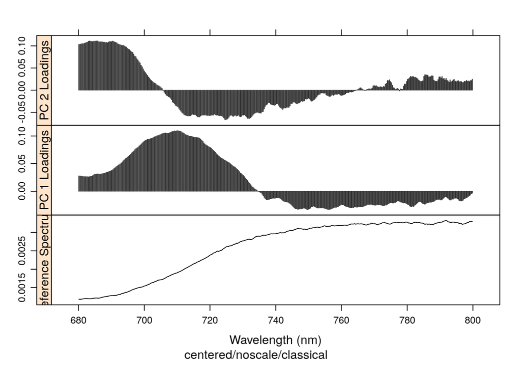

```r
plotLoadings(spec3, pca, loads = c(1,2))
```

## potential outliers

The function “pcaDiag” can produce two types of plots shown below that can be helpful in detecting outliers

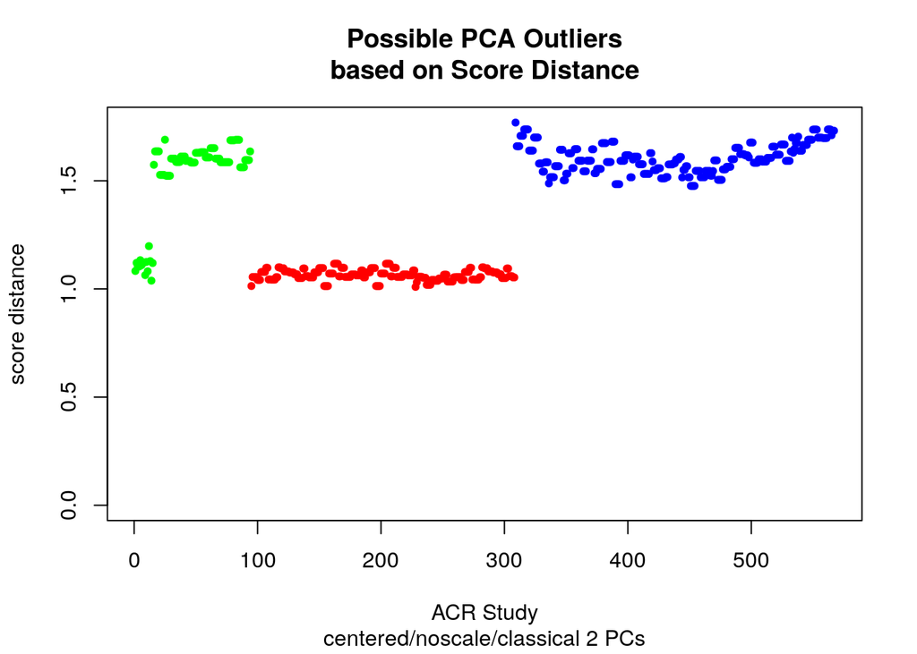

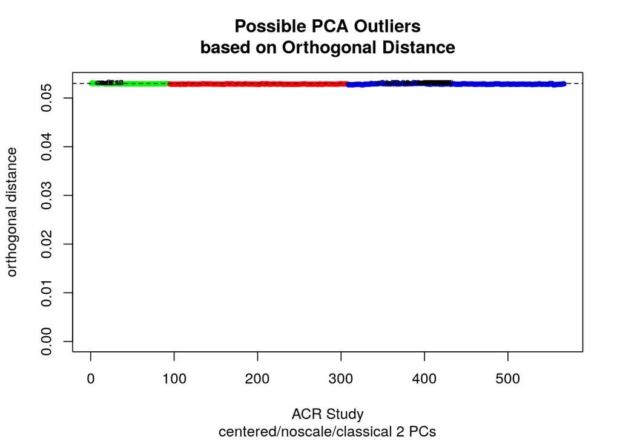

```r
diagnostics<-pcaDiag(spec3,
                     pca,
                     pcs = 2,
                     #quantile = 0,95,
                     plot = c("OD","SD"))
```

## Scree Plots

This plot determine the number of PCs needed to describe the data by showing the cumulative variance of the PCs

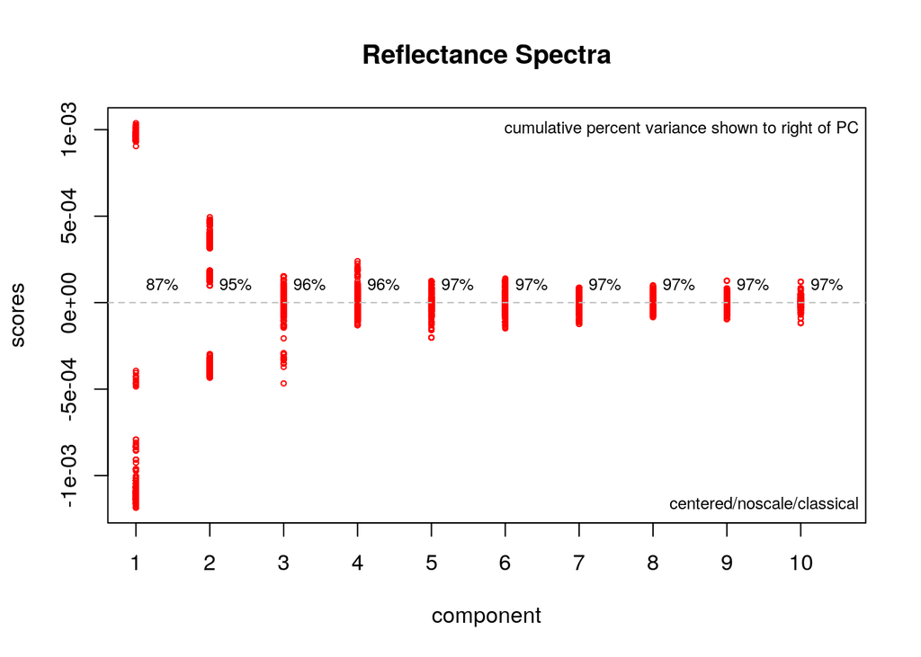

```r
plotScree(pca,style = "alt",main="Reflectance Spectra")
```

All the functions and terminology used in this presentation, that i did not get the chance to explain in our earlier session are available in details. please make sure to check them and some chemospec vignettes [here](https://www.rdocumentation.org/packages/ChemoSpec/versions/5.2.12).